# Speech emotion analysis: extralingustic feature influence on embarrasment detection for French and Russian

10.06.2018

### Materials

[Link to the data set](https://github.com/lilaspourpre/Linguistic-data-quantitative-analysis-and-visualisation/blob/master/project/dataset_embarr.csv) (csv file)  
[Link to audio](https://github.com/lilaspourpre/Linguistic-data-quantitative-analysis-and-visualisation/tree/master/project/audio)  
[Link to questionnaire](https://docs.google.com/forms/d/e/1FAIpQLSf6uuyYNl8ZlWfX3knrF-04q35faGCwP83PXebmEK59VTFQCA/viewform)

## Introduction

### Describe the phenomenon.

Embarrassment as other emotions mainly is the object of studies of psychology. For instance, (Goffman, 1967) describes embarrassment as expression of opinion about our actions that do not suit the situation. (Borg et al., 1988) understand embarrassment as a type of shame, (Edelman, 1985) treats embarrassment as anxiety. The idea of these studies was to determine the notion of embarrassment and to understand the reasons of it. To add, these studies agree that there is such emotion as embarrassment but no study highlight if people can understand whether a person is embarrassed. There are several ways to understand it. First, as signals of embarrassment the mimic, the actions of a person can be considered. That is what was done by psychologists. Secondly, the linguistics features can be taken into account. That was described in the previous study that is mentioned below. However, the success in understanding embarrassment might base not only on the ability of a speaker to express it but also on the ability of a listener to understand it. In this study we try to understand if there is the connection between listenersвЂ™ characteristics as gender, age, level of education and foreign language command and this ability.

### Mention some previous research (optional).

This research is not started from scratch as it is based on the previous research of embarrassment on speech that was conducted as a part of the Research Seminar under the supervision of Bukharov V. M. during BA program. However, the current research is different from the previous one as extra linguistics factors are found under the examination. To add, the previous study was extended so in the current research not only Russian but also French is taken into consideration that allows to check whether the language command and the language of audios might affect the level of embarrassment recognition.

## Research hypothesis

In the current research we asssume that precision of embarrassment recognition do not depend on extra linguistic factors: gender, age, education and foreign language aquisition so as the null hypothesis we consider that the mentioned extralinguistic factors do not influence the precision level. This means that people from different categories might be successful or unsuccessful in detecting embarrassment in speech in the same way.

## R libraries in use

```r
library(tidyverse)
```

```r
library(ggplot2)
library(lme4)
library(tidyr)
library(irr)
library(FactoMineR)
library(factoextra)
```

## Data

The current section id devoted to dataset description and the transformations applied to the dataset in order to being able to manipulate with data.

### Data collection and annotation

Each of those phrases were voiced and recorded by 2 native Russian speakers (M and F, 22 y.o.). However, in the current research we compare emberrassment detection for Russian and French, so we translated the above mentioned sentences (with a C1-level certificated interpreter and further native speaker revision) into French. Then we asked 2 native French speakers (M and F, 22 y.o.) to record the phrases. Source and target sentences are provided below:

[output not shown]

After that, we ran a questionnaire with 5 questions of “hard data” type (age, gender, education, foreign languages) and 20 questions about embarrassment measurement in audios. The respondents we suggested to listen to each audio (with Russian and French records) and to score embarrassment expression level in each audio from 0 to 5.

We also discovered the appropriate number of respondents considering the amount of parameters (predictor variables) and with the usage of power test. We use the following code:

```r
power.anova.test(groups = 64, between.var = 1, within.var = 3,
                 power = .80)
```

```
##
##      Balanced one-way analysis of variance power calculation
##
##          groups = 64
##               n = 2.317563
##     between.var = 1
##      within.var = 3
##       sig.level = 0.05
##           power = 0.8
##
## NOTE: n is number in each group
```

Number of groups = 2(levels of gender) * 4 (levels of age) * 2 (levels of education) * 2 (levels of English aquisition) * 2 (levels of french aquisition) = 2 * 4 * 2 * 2 * 2 = 2^6 = 64. We suppose betweeb.var=1 and within.var as signifiant. Thus, our minimum number of respondents should not be less than 2.31 * 64 = 147.84 (~150). By the start of our research, the questionnaire includes 216 responces.

It is rather obvious that our dataset is not as brilliant as it might seem at first glance. Binary type of language aquisition does not represent the actual language knowledge. The same problem might appear with age. MOreover, the dataset format is not applicable for deep analysis. First of all, the data should be standardized. Secodly, to calculate lm we have to transform the data to long format. To add, we change the way of answer presenting of the categodies as Education, the language command (ability to speak foreign languages). So the raw data cannot be used. To add, as we are going to see below the data cannot provide statistically significant results that may help us to explain different dependencies and build models using the data.

### Data formatting

First of all, it should be mentioned that our dataset comprises 216 responces from questionnaire as 216 rows and 25 columns. As our dependent variable is the precision value that permits to measure evaluation performance. However, in our dataset we have absolur numbers, that is why we standardize the values by dividing each by 5 as we believe that each phrase of each rater should heva score equal to 5.

Noreover, we also need to change for English and French knowledge representation from binary values 0 and 1 to factors (“English yes”, “English no” and “French yes”, “French no”). Moreover, we add ID column for rater identification.

```r
embarr <- read.csv("dataset_embarr.csv")
embarr$English <- ifelse(embarr$English==1, "English yes", "English no")
embarr$French <- ifelse(embarr$French==1, "French yes", "French no")
embarr$Age <- as.factor(as.character(embarr$Age))
embarr$English <- as.factor(embarr$English)
embarr$French <- as.factor(embarr$French)
embarr$ID <- c(1:length(embarr$Age))
embarr[, 6:25] <- data.frame(t(apply(embarr[,  6:25], 1, function(x) {x / 5})))
```

Furthermore, for creating plots and conducting further analysis we transform the data to long format and add a new column that contains the speaker.

```r
#transforming the data to long format
embarr %>%
  gather(Phrase, Value, A1.1:E2.2) ->
embarr.long

#adding the Speaker
embarr.long %>%
  mutate(speaker = str_extract(Phrase, "[12]\\.[12]"),
         speaker_1 = str_extract(speaker, "[12]$"),
         speaker_2 = str_extract(speaker, "^[12]"),
         speaker = if_else(speaker_1 == 1 &
                             speaker_2 == 1,
                           "Speaker 1",
                           if_else(speaker_1 == 1 &
                                     speaker_2 == 2,
                                   "Speaker 2",
                                   if_else(speaker_1 == 2 &
                                             speaker_2 == 1,
                                           "Speaker 3",
                                           "Speaker 4")))) %>%
  select(-speaker_1, -speaker_2) ->
           embarr.long
```

- Our predictor variables are mostly categorical:
1. age (categorical):
- 18-25
- 25-30
- 30-35
- 35-40
2. gender (categorical):
- M
- F
3. education (categorical):
- Secondary
- Higher
4. English knowledge (binary, categorical):
- 0 (no)
- 1 (yes)
5. French knowledge (binary, categorical):
- 0 (no)
- 1 (yes)

### Data considerations

One of the most obvious possible bias in our data is the non-professionalism of speaker and the expressiveness of their embarrassement in speech. Moreover, other external parameters might also be important for detecting dependencies, however, the are out of the scope of our research.

## Analysis: descriptive statistics

First of all, we counted all posible statistical info:

| Age | NumOfRespondents |
| --- | --- |
| 18-25 | 57 |
| 26-30 | 52 |
| 31-35 | 52 |
| 36-40 | 55 |

| Gender | NumOfRespondents |
| --- | --- |
| F | 107 |
| M | 109 |

| Education | NumOfRespondents |
| --- | --- |
| Higher | 112 |
| Secondary | 104 |

| English | NumOfRespondents |
| --- | --- |
| 0 | 103 |
| 1 | 113 |

| French | NumOfRespondents |
| --- | --- |
| 0 | 109 |
| 1 | 107 |

Moreover, we measured inter-rater agreement for each phrase using raw (non-standatized data). This measure could be applied as we if we consider our task to evaluate speaker performance.

```r
embarrKappa <- read.csv("https://raw.githubusercontent.com/lilaspourpre/Linguistic-data-quantitative-analysis-and-visualisation/master/project/dataset_embarr.csv")
embarrKappa$English <- ifelse(embarrKappa$English==1, "English yes", "English no")
embarrKappa$French <- ifelse(embarrKappa$French==1, "French yes", "French no")
embarrKappa$ID <- c(1:length(embarrKappa$Age))

#Kappa
embarrKappa %>%
  select(6:25) -> embarr.short
emb<- data.frame(t(embarr.short))
icc(emb)
```

```
##  Single Score Intraclass Correlation
##
##    Model: oneway
##    Type : consistency
##
##    Subjects = 20
##      Raters = 216
##      ICC(1) = 0.0619
##
##  F-Test, H0: r0 = 0 ; H1: r0 > 0
##  F(19,4300) = 15.2 , p = 1.64e-48
##
##  95%-Confidence Interval for ICC Population Values:
##   0.035 < ICC < 0.127
```

From the results we can see that the inter-rater ageement is very small that means that raters score the audios differently.

In order to provide more statistica about the data we take a look at the distrubution of the average values for each speaker and for each audio.

```r
embarr %>%
  select(6:25) %>%
  colMeans() -> means.embarr
means <- data.frame(questions = c('A1.1', 'A1.2', 'B1.1', 'B1.2', 'C1.1', 'C1.2', 'D1.1', 'D1.2', 'E1.1', 'E1.2', 'A2.1', 'A2.2', 'B2.1', 'B2.2', 'C2.1', 'C2.2', 'D2.1', 'D2.2', 'E2.1', 'E2.2'), speaker=c("Speaker 1", "Speaker 2", "Speaker 1", "Speaker 2", "Speaker 1", "Speaker 2", "Speaker 1", "Speaker 2", "Speaker 1", "Speaker 2", "Speaker 3", "Speaker 4", "Speaker 3", "Speaker 4", "Speaker 3", "Speaker 4", "Speaker 3", "Speaker 4", "Speaker 3", "Speaker 4"),  means = means.embarr)
```

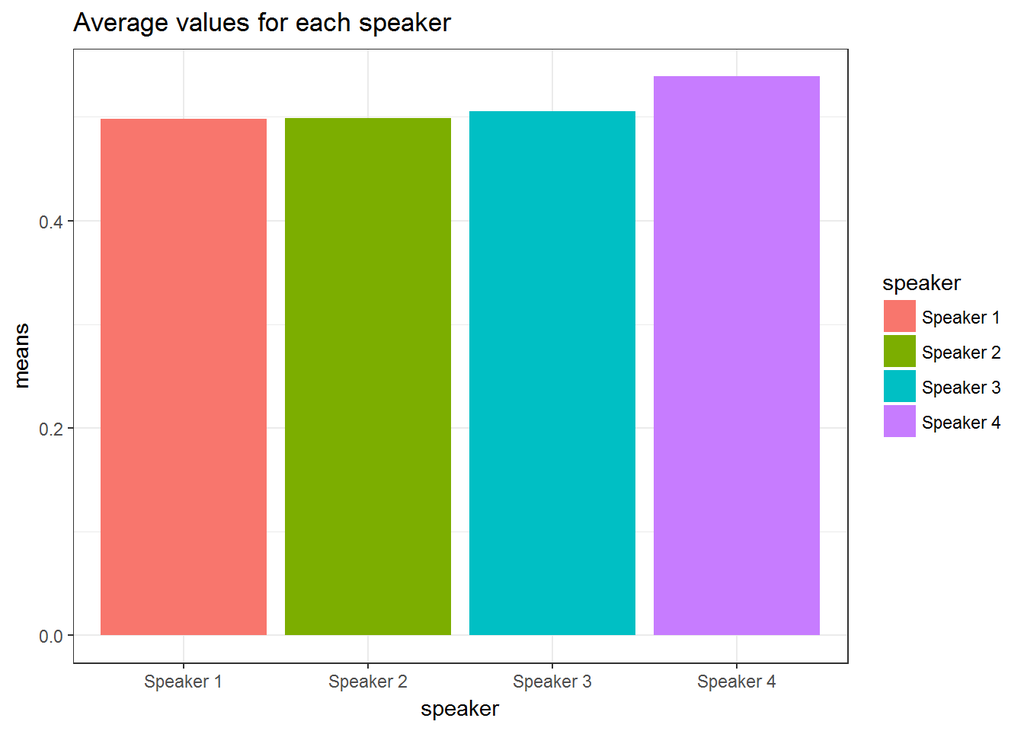

```r
ggplot(means,aes(x = speaker,y = means)) +
    geom_bar(aes(fill = speaker),stat = "identity",position = "dodge")+ theme_bw()+labs(title = "Average values for each speaker")
```

From the table we may see that the fourth speaker gets slightly higher results than other.

Also, we can check how good is the speaker in faking the emotion by compring the results of different groups

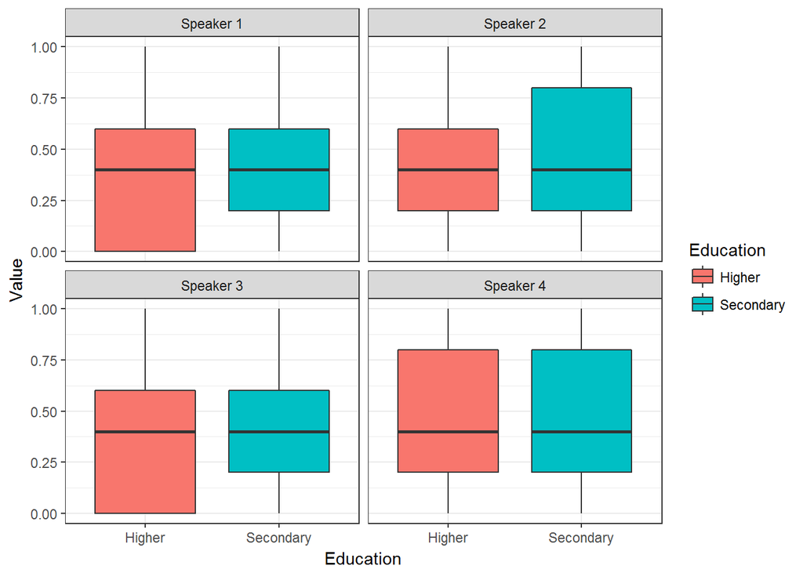

```r
embarr.long  %>%
  ggplot(aes(Education,Value, fill=Education)) +
  geom_boxplot() +
  facet_wrap(~speaker)+ theme_bw()
```

It is seen from the plot that the fourth speaker has higher scores. To add, people with secondary education give the higher marks for the perfomance of the second speaker and this group gives average scores whereas the group of higher education tends to give lower and average marks.

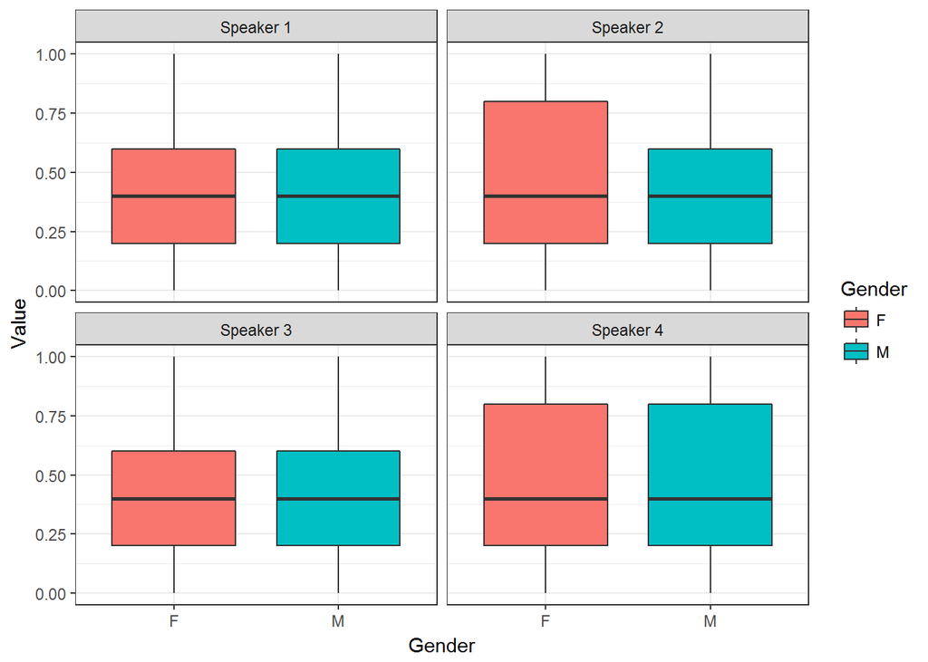

```r
embarr.long  %>%
  ggplot(aes(Gender,Value, fill=Gender)) +
  geom_boxplot() +
  facet_wrap(~speaker)+ theme_bw()
```

According to the gender distribution the preference goes to the second speaker as females think that the speech of the second speaker has more emotions. However, the results of the forth one are still high.

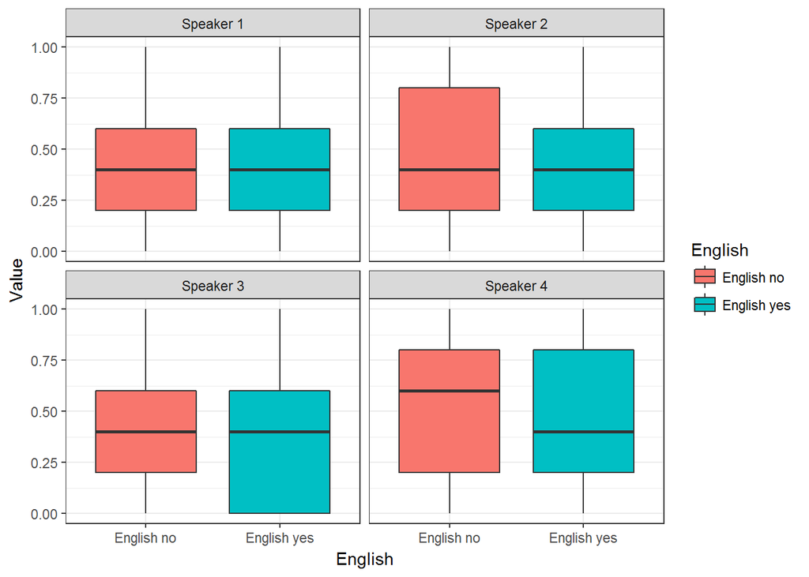

```r
embarr.long  %>%
  ggplot(aes(English,Value, fill=English)) +
  geom_boxplot() +
  facet_wrap(~speaker)+theme_bw()
```

The same pattern can be seen in the distribution by the ability to speak English. It should be said that speaker 3 who is French has lower scores among people who can speak English so it might be the knowlage of a foreign language might influence on the results. The same pattern can be seen for the distribution by the ability to speak French.

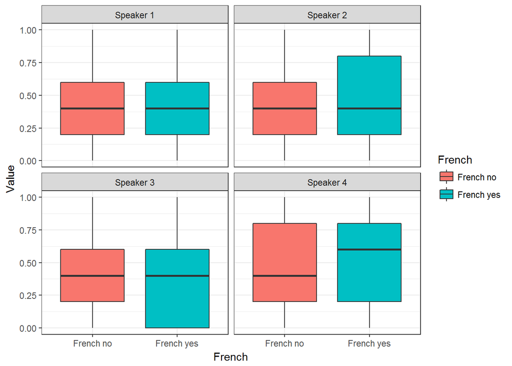

```r
embarr.long  %>%
  ggplot(aes(French,Value, fill=French)) +
  geom_boxplot() +
  facet_wrap(~speaker)+theme_bw()
```

From the plot it can be seen that speaker 4 recieves the highest marks whereas speaker 1, apeaker 2 and speaker 3 have quite the same results.

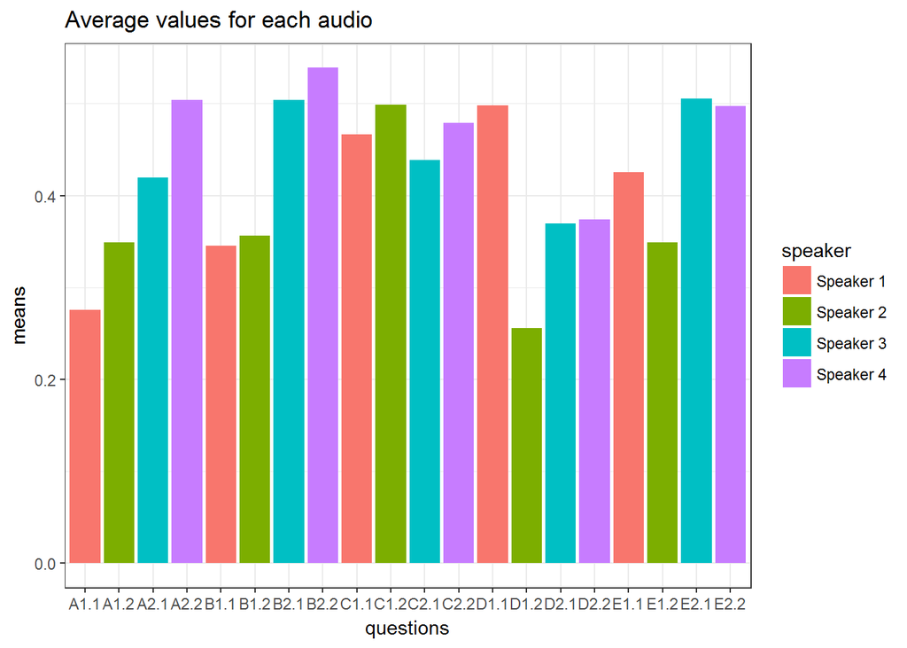

```r
ggplot(means,aes(x = questions,y = means)) +
    geom_bar(aes(fill = speaker),stat = "identity",position = "dodge")+ theme_bw()+labs(title = "Average values for each audio")
```

From the plot the ditrubition of values is shown for each audio with respect to the speaker. As an interesting fact it can be point out that the average values for Russian audios are lower than the average values for French audios (compare A1.1 and A2.1, B1.2 and B2.1). To have more detailed information the following plots can be considered.

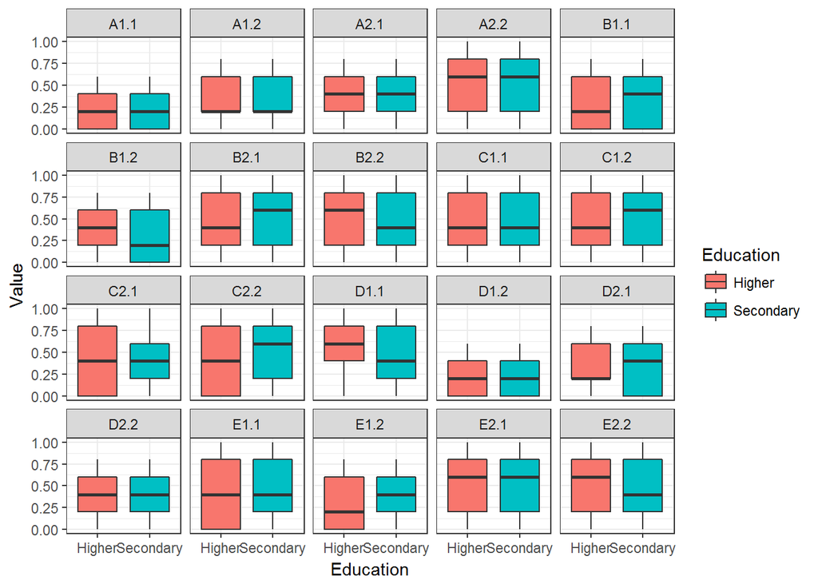

```r
embarr.long  %>%
  ggplot(aes(Education,Value, fill=Education)) +
  geom_boxplot() +
  facet_wrap(~Phrase)+theme_bw()
```

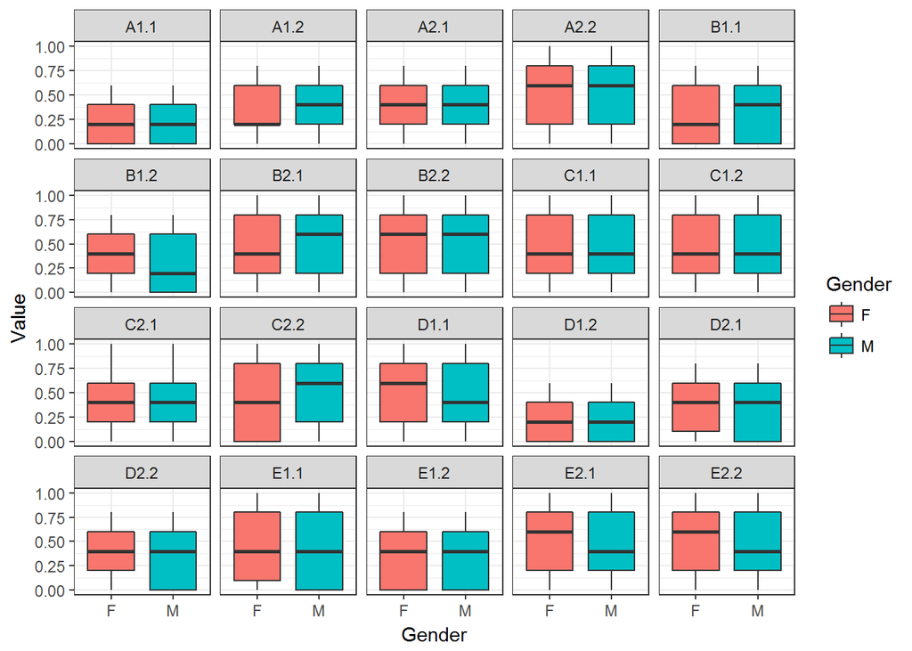

```r
embarr.long  %>%
  ggplot(aes(Gender,Value, fill=Gender)) +
  geom_boxplot() +
  facet_wrap(~Phrase)+theme_bw()
```

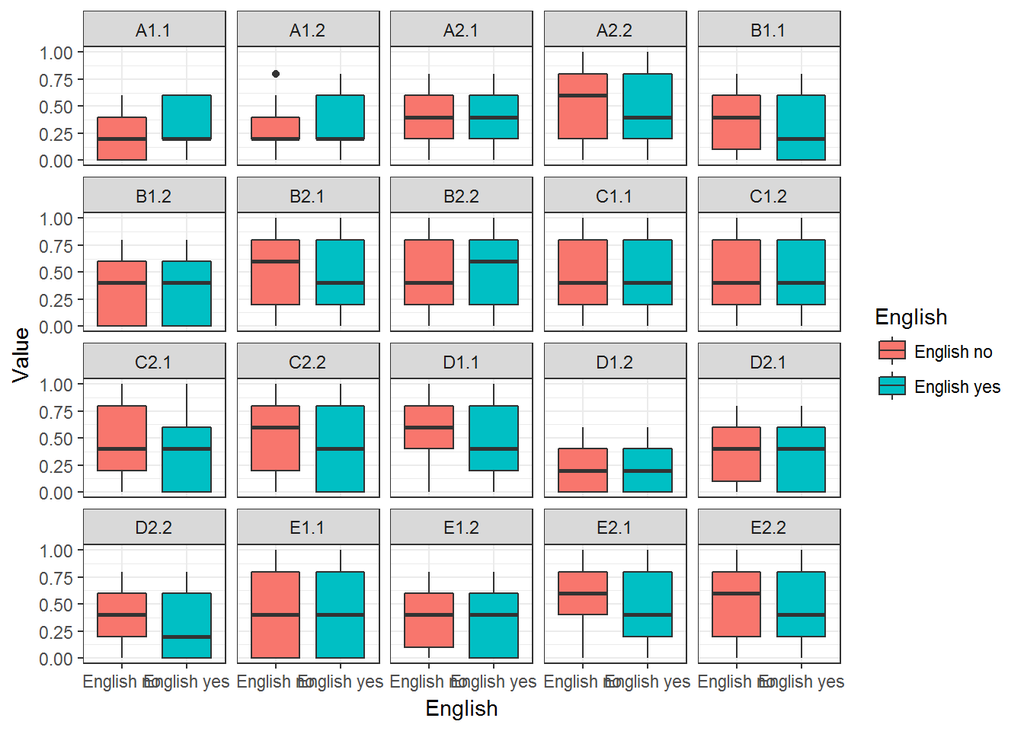

```r
embarr.long  %>%
  ggplot(aes(English,Value, fill=English)) +
  geom_boxplot() +
  facet_wrap(~Phrase)+theme_bw()
```

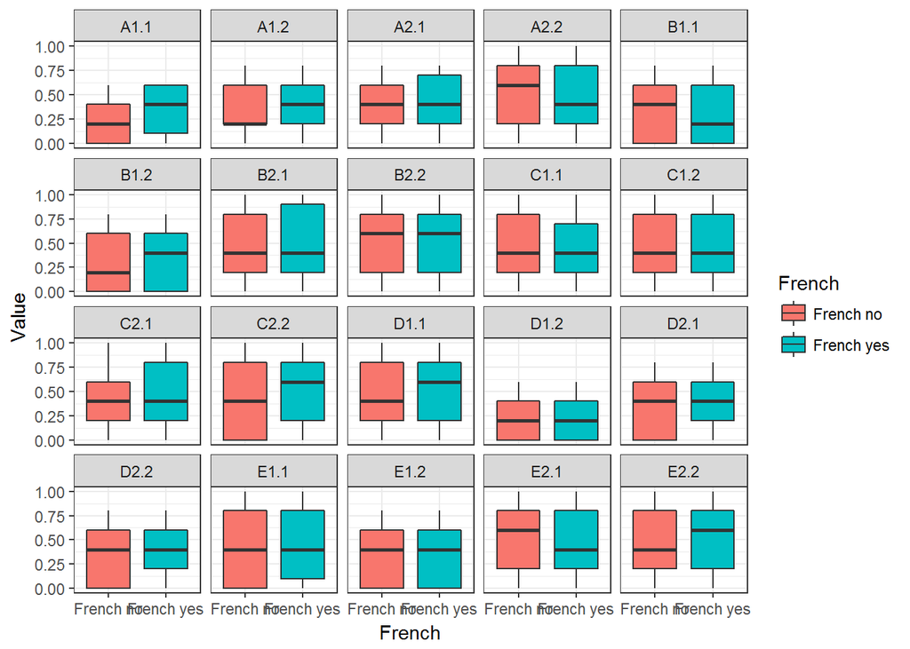

```r
embarr.long  %>%
  ggplot(aes(French,Value, fill=French)) +
  geom_boxplot() +
  facet_wrap(~Phrase)+theme_bw()
```

To summarize these results the violin plot is built. This plot can be built for each phrase (the example is for phrase A2.1). The plot illustrates the ditrubution of the results for each audio according to the gender, the level of education and the ability to speak English or French.

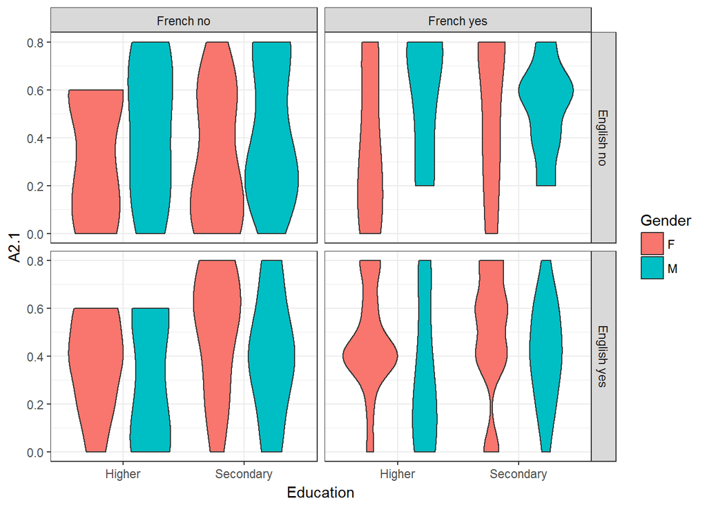

```r
embarr %>%
  ggplot(aes(Education, A2.1, fill = Gender))+
  geom_violin()+
  facet_grid(English~French)+ theme_bw()
```

## Linear Regression

For testing our hypothesis we use Linear Regression model with speaker as ranfom effect

```r
lm_r <- lmer(Value~Age+Gender+Education+English+ French + (1|speaker), data=embarr.long)
summary(lm_r)
```

```
## Linear mixed model fit by REML ['lmerMod']
## Formula:
## Value ~ Age + Gender + Education + English + French + (1 | speaker)
##    Data: embarr.long
##
## REML criterion at convergence: 2458.9
##
## Scaled residuals:
##      Min       1Q   Median       3Q      Max
## -1.66423 -0.83198 -0.05958  0.78218  2.16114
##
## Random effects:
##  Groups   Name        Variance Std.Dev.
##  speaker  (Intercept) 0.002522 0.05021
##  Residual             0.101989 0.31936
## Number of obs: 4320, groups:  speaker, 4
##
## Fixed effects:
##                     Estimate Std. Error t value
## (Intercept)         0.400232   0.028544  14.022
## Age30               0.005390   0.013704   0.393
## Age35               0.040383   0.013718   2.944
## Age40               0.042290   0.013507   3.131
## GenderM            -0.006396   0.009732  -0.657
## EducationSecondary  0.017591   0.009738   1.806
## EnglishEnglish yes -0.025554   0.009744  -2.622
## FrenchFrench yes    0.017374   0.009724   1.787
##
## Correlation of Fixed Effects:
##             (Intr) Age30  Age35  Age40  GendrM EdctnS EnglEy
## Age30       -0.230
## Age35       -0.226  0.478
## Age40       -0.226  0.484  0.485
## GenderM     -0.160 -0.018 -0.045 -0.025
## EdctnScndry -0.173  0.022  0.009  0.001 -0.009
## EnglshEngly -0.196  0.018  0.031  0.012  0.017  0.045
## FrnchFrnchy -0.157 -0.019 -0.018 -0.025 -0.018 -0.009 -0.002
```

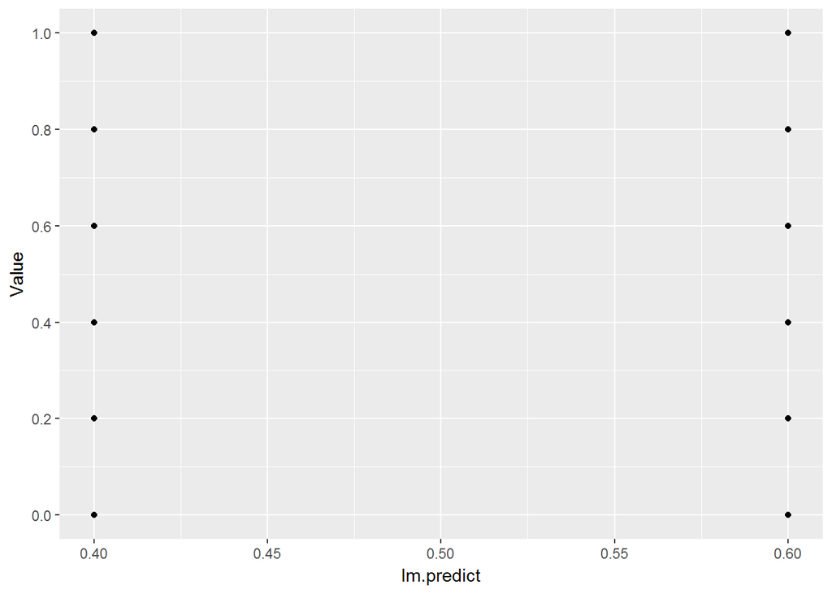

```r
embarr.long$lm.predict <- predict(lm_r)
for (i in 1:length(embarr.long$lm.predict)){
  a <- embarr.long$lm.predict[i]
  if (a > 0 && a <= 0.1)
    embarr.long$lm.predict[i] <- 0
  if (a > 0.1 && a <= 0.3)
    embarr.long$lm.predict[i] <- 0.2

  if (a > 0.3 && a <= 0.5)
    embarr.long$lm.predict[i] <- 0.4

  if (a > 0.5 && a <= 0.7)
    embarr.long$lm.predict[i] <- 0.6

  if (a > 0.7 && a <= 0.9)
    embarr.long$lm.predict[i] <- 0.8

  if (a > 0.9 && a <= 1)
    embarr.long$lm.predict[i] <- 1
}
embarr.long %>% ggplot(aes(lm.predict, Value)) + geom_point() + scale_y_continuous(breaks=seq(0,1,0.2))
```

## FAMD

Moreover, we use Factor analysis of mixed data (FAMD) dedicated to analyze dataset containing both quantitative and qualitative variables (Pages 2004).

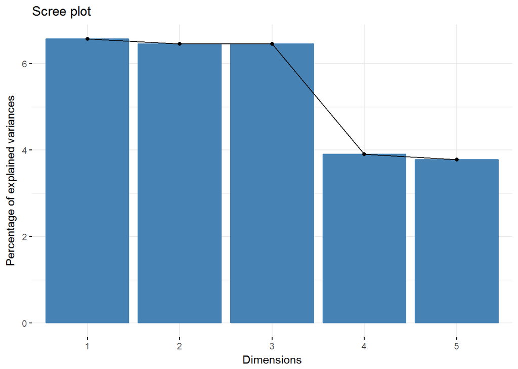

```r
res.famd <- FAMD(embarr.long[, 1:9], graph = FALSE)

fviz_screeplot(res.famd)
```

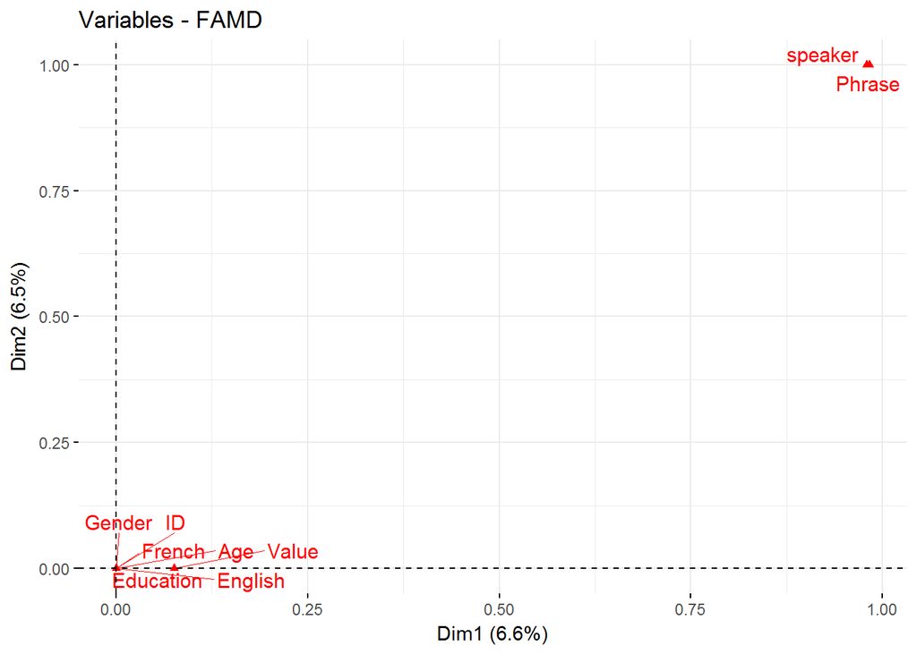

```r
# Plot of variables
fviz_famd_var(res.famd, repel = TRUE)
```

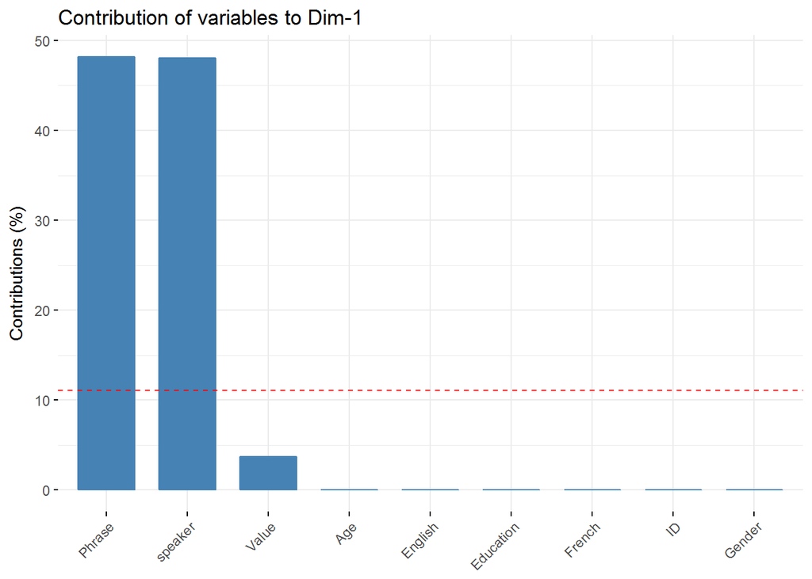

```r
# Contribution to the first dimension
fviz_contrib(res.famd, "var", axes = 1)
```

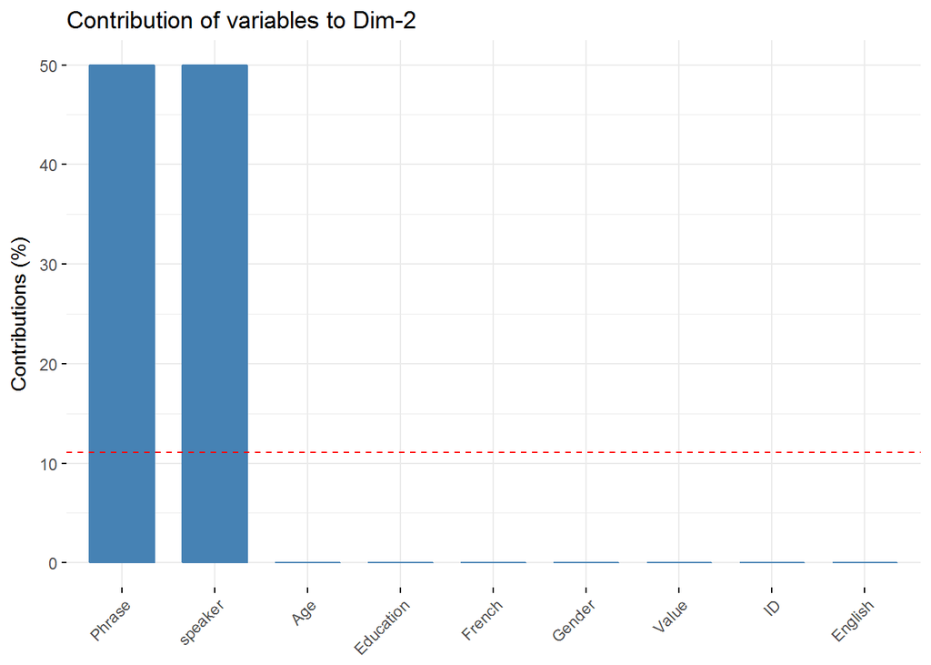

```r
# Contribution to the second dimension
fviz_contrib(res.famd, "var", axes = 2)
```

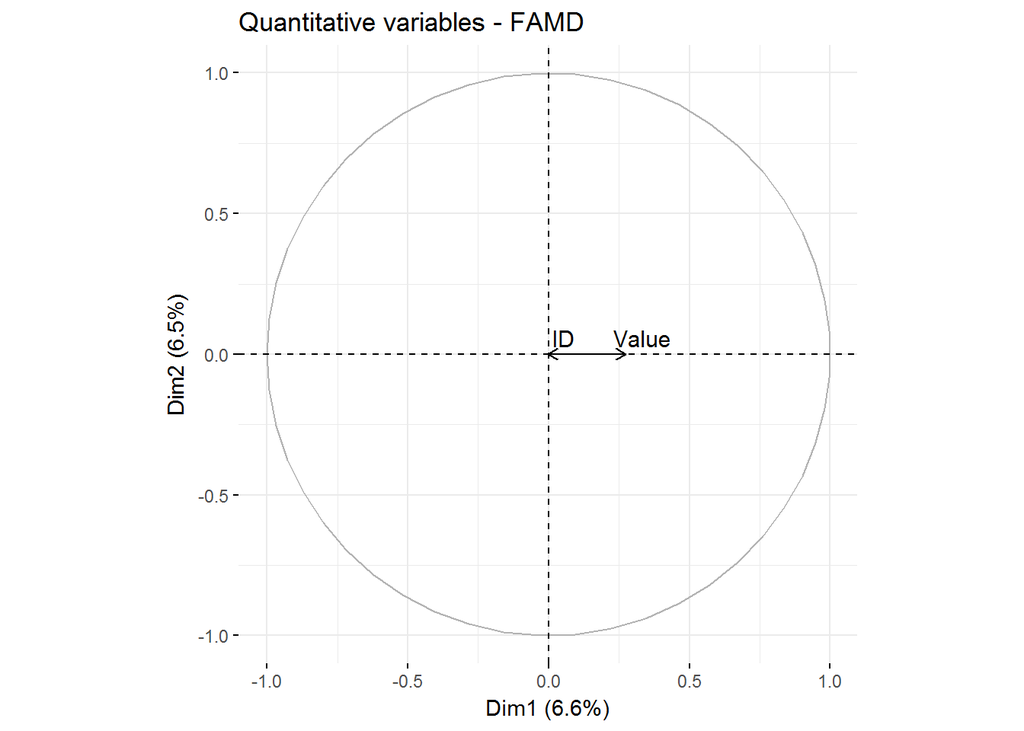

```r
fviz_famd_var(res.famd, "quanti.var", repel = TRUE,
              col.var = "black")
```

As we can see from the plots, none of extralinguistic variables are chosen as significant for dimenstion reduction. By the way, the obtained results approve the results of LR model and vice versa.

## Discussion on data distribution and quantitative methods in use

It is suggested to provide the dataset that would be more accurate.To add, as it was pointed out it the comments to the survey it is diffucult to fake the embarrassment and only audios might be not enought to spot the emotion. So it can be a good idea to replace the audio with videos. Furthermore, it might be a good idea to study not only listeners characteristics but also speaker characteristics as it might show that different speakers express the emotion in the different way.